# Arshad_FaazHw2.Rmd

# Added abbreviations to states on the map.

```r
state.abb
```

```
##  [1] "AL" "AK" "AZ" "AR" "CA" "CO" "CT" "DE" "FL" "GA" "HI" "ID" "IL" "IN" "IA"
## [16] "KS" "KY" "LA" "ME" "MD" "MA" "MI" "MN" "MS" "MO" "MT" "NE" "NV" "NH" "NJ"
## [31] "NM" "NY" "NC" "ND" "OH" "OK" "OR" "PA" "RI" "SC" "SD" "TN" "TX" "UT" "VT"
## [46] "VA" "WA" "WV" "WI" "WY"
```

```r
state.name
```

```
##  [1] "Alabama"        "Alaska"         "Arizona"        "Arkansas"
##  [5] "California"     "Colorado"       "Connecticut"    "Delaware"
##  [9] "Florida"        "Georgia"        "Hawaii"         "Idaho"
## [13] "Illinois"       "Indiana"        "Iowa"           "Kansas"
## [17] "Kentucky"       "Louisiana"      "Maine"          "Maryland"
## [21] "Massachusetts"  "Michigan"       "Minnesota"      "Mississippi"
## [25] "Missouri"       "Montana"        "Nebraska"       "Nevada"
## [29] "New Hampshire"  "New Jersey"     "New Mexico"     "New York"
## [33] "North Carolina" "North Dakota"   "Ohio"           "Oklahoma"
## [37] "Oregon"         "Pennsylvania"   "Rhode Island"   "South Carolina"
## [41] "South Dakota"   "Tennessee"      "Texas"          "Utah"
## [45] "Vermont"        "Virginia"       "Washington"     "West Virginia"
## [49] "Wisconsin"      "Wyoming"
```

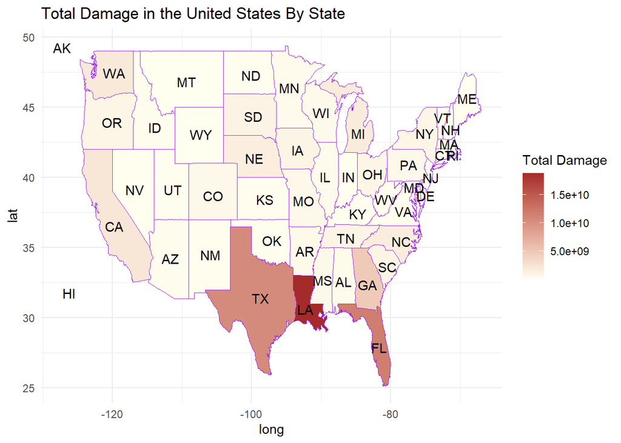

```r
adding_abbreviations <- data.frame (region=tolower(state.name), long=state.center$x, lat = state.center$y)

adding_abbreviations$abb<- state.abb[match(adding_abbreviations$region, tolower(state.name))]


stormmap2 <- stormmap + with (adding_abbreviations, annotate (geom = "text", x = long, y = lat, label = abb, color = "black"))

stormmap2
```

# County Chloropleth Maps

# 1b) Provide a static county-level choropleth map of the United States visualizing where monetary damage is recorded (by using the sum of the variables damage property USD and damage crop USD.

# Calculated sum.

```r
storms$sum1 <-storms$DAMAGE_CROPS_USD+storms$DAMAGE_PROPERTY_USD
head(storms$sum1)
```

```
## [1] 110000   1000   5000      0  10000   2000
```

```r
uscounties_sf <- get_urbn_map("counties", sf = TRUE)
str(uscounties_sf)
```

```
## Classes 'sf' and 'data.frame':   3142 obs. of  7 variables:
##  $ county_fips: chr  "04015" "12035" "20129" "28093" ...
##  $ state_abbv : chr  "AZ" "FL" "KS" "MS" ...
##  $ state_fips : chr  "04" "12" "20" "28" ...
##  $ county_name: chr  "Mohave County" "Flagler County" "Morton County" "Marshall County" ...
##  $ fips_class : chr  "H1" "H1" "H1" "H1" ...
##  $ state_name : chr  "Arizona" "Florida" "Kansas" "Mississippi" ...
##  $ geometry   :sfc_MULTIPOLYGON of length 3142; first list element: List of 1
##   ..$ :List of 1
##   .. ..$ : num [1:1023, 1:2] -1321573 -1321334 -1320642 -1319546 -1317819 ...
##   ..- attr(*, "class")= chr [1:3] "XY" "MULTIPOLYGON" "sfg"
##  - attr(*, "sf_column")= chr "geometry"
##  - attr(*, "agr")= Factor w/ 3 levels "constant","aggregate",..: NA NA NA NA NA NA
##   ..- attr(*, "names")= chr [1:6] "county_fips" "state_abbv" "state_fips" "county_name" ...
```

```r
countyS <- storms %>%
  filter(CZ_TYPE == "C")%>%
  group_by(CZ_NAME) %>%
  summarise(damage = sum(DAMAGE_PROPERTY_USD, na.rm = TRUE) + sum(DAMAGE_CROPS_USD,na.rm = TRUE))
head(countyS)
```

```
## # A tibble: 6 × 2
##   CZ_NAME      damage
##   <chr>         <dbl>
## 1 ABBEVILLE    215000
## 2 ACADIA      1204000
## 3 ACCOMACK      46250
## 4 ADA         4000000
## 5 ADAIR       3081000
## 6 ADAMS     109880450
```

# Below is the code to produce the county-level plot for 1b.

[figure not shown]

```r
### My knitting was not working properly for this image so I screen shotted it so you can see my output.
knitr::include_graphics("USCounty.png")
```

```r
#ggplot()+
#    geom_sf(data = uscounties_sf,aes(fill = countyS$damage, color = "#ffffff"))+
#    guides (color = FALSE)+
#    labs
```

# Density Map

# 1c) Provide a map, in which you highlight the density of sever events by focusing on the variables of injuries and or deaths associated with storms. Discuss briefly which of the two approaches provide a better visual summer of the distribution of the destructive effects of storms.

# Calculated the sum for injuries.

```r
combined1$suminjuries <- combined1$INJURIES_DIRECT + combined1$INJURIES_INDIRECT
head(combined1$suminjuries)
```

```
## [1] 1 0 0 0 0 0
```

# Calculated the sum for deaths.

```r
combined1$sumdeaths <- combined1$DEATHS_DIRECT + combined1$DEATHS_INDIRECT
head(combined1$sumdeaths)
```

```
## [1] 0 0 0 0 0 0
```

# Used API key.

```r
library(ggmap)
register_google(key = "AIzaSyAyd2Y9c8XGkV3G5FGk-M7Tlk5UyPLd7gE", write = TRUE)
```

```
## ℹ Replacing old key (AIzaSyAyd2Y9c8XGkV3G5FGk) with new key in C:\Users\faaz2\OneDrive\Documents/.Renviron
```

```r
map_US <- get_map (location = "united states", zoom = 4)
map_US <- ggmap (map_US)
```